# Time Series Analysis - STAT 478 - HW #6

Alex Towell (atowell@siue.edu)

# Problem 1

A data set of 324 measurements of an industrial robot’s positions are in the robot object in the TSA package.

```r
library(TSA)
data(robot)
head(robot)
```

```
## [1]  0.0011  0.0011  0.0024  0.0000 -0.0018  0.0055
```

## Preliminary analysis

We denote the industrial robot’s position time series as $\{P_t\}$. A quick plot:

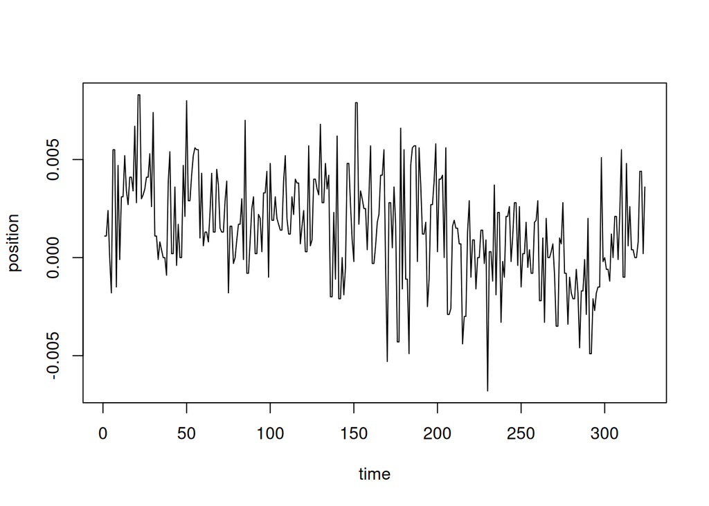

```r
plot(robot,xlab="time",ylab="position")
```

## Part (a)

We suppose that $\{P_t\} \sim \operatorname{AR}(1)$, defined as
$$P_t = c + \phi P_{t-1} + e_t$$
where $e_t$ are the residuals in the model. If the model is a good fit, $e_t$ approximates $\operatorname{WN}(0,\sigma_e^2)$, zero-mean white noise.

We fit the data to the $\operatorname{AR}(1)$ model with:

```r
robot.ar1 <- arima(robot,order=c(1,0,0))
print(robot.ar1)
```

```
##
## Call:
## arima(x = robot, order = c(1, 0, 0))
##
## Coefficients:
##          ar1  intercept
##       0.3074     0.0015
## s.e.  0.0528     0.0002
##
## sigma^2 estimated as 6.482e-06:  log likelihood = 1475.54,  aic = -2947.08
```

```r
robot.ar1.phi <- coef(robot.ar1)[1]
robot.ar1.c <- coef(robot.ar1)[2]
robot.ar1.mu <- robot.ar1.c / (1-robot.ar1.phi^2)

# robot.ar1.resid <- robot.ar1 - robot
# plot(robot.ar1.resid)
# robot.ar1.resid.mu <- mean(robot.ar1.resid)
# print(robot.ar1.resid.mu)
# robot.ar1.resid.var <- var(robot.ar1.resid)
# print(robot.ar1.resid.var)
```

Note that the sample mean and sample variance of $\{P_t\}$ is given respectively by $0.0014515$ and $7.1844868\times 10^{-6}$, which is reasonably close to the $\operatorname{AR}(1)$ model estimates. However, we need the residuals of this model to model white noise for this to be a good model of $\{P_t\}$, which we check for next.

## Part (b)

We do time series and Q-Q plots of the standardized residuals with:

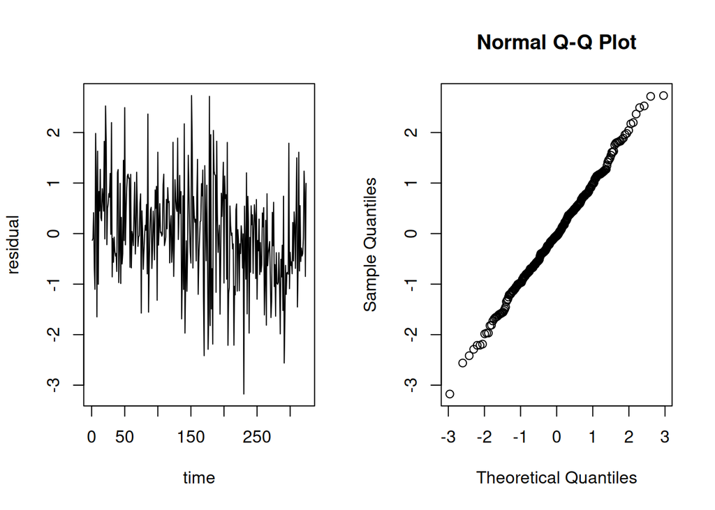

```r
par(mfrow=c(1,2))
plot(rstandard(robot.ar1), xlab="time", ylab="residual")
qqnorm(rstandard(robot.ar1))
```

The Q-Q plot is consistent with normality, but there may be an issue with the time series plot of the residuals, which does not appear to model zero mean white noise. There appears to be some regularity in the residuals which should be captured by our model.

## Part (c)

First, we plot the sample ACF:

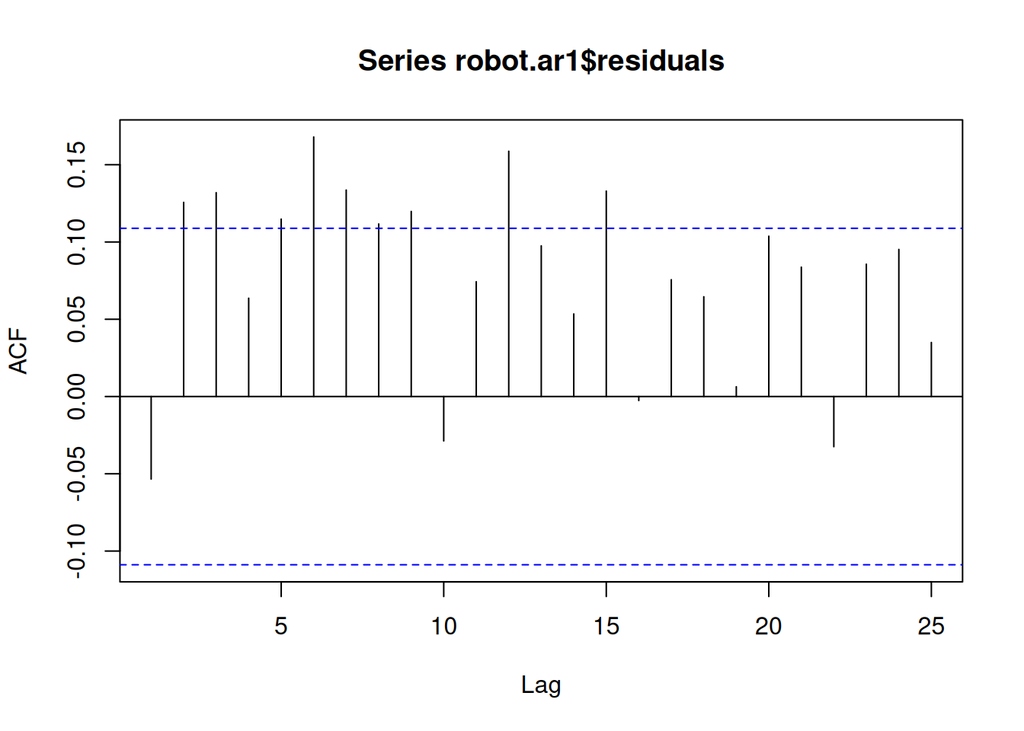

```r
acf(robot.ar1$residuals)
```

The sample ACF does not indicate zero mean white noise since we see autocorrelations that frequently fall outside of the confidence intervals for zero mean white noise.

However, it may be difficult to determine from these plots whether the ACF is compatible with white noise when we look at the lags separately. We perform the Ljung-Box to perform the hypothesis test
$$H_0 : r_1 = r_2 = \cdots = r_{30} = 0$$
whose test statistic is $\chi^2$ distributed with $\operatorname{df} = K-p = 29$ degrees of freedom under the null hypothesis of zero mean white noise.

```r
K <- 30
p <- 1
q <- 0
Box.test(robot.ar1$residuals,
         lag=K,
         type="Ljung-Box",
         fitdf=p+q)
```

```
##
##  Box-Ljung test
##
## data:  robot.ar1$residuals
## X-squared = 83.243, df = 29, p-value = 3.845e-07
```

We see that the probability that a white noise process generates the observed test statistic $X^2 = 83.243$ occurs with probability less than $0.001$, which we consider to be very strong evidence against the hypothesis that the residuals are a zero mean white noise process.

We conclude that the model fails to capture some of the regularity in the time series data. We would prefer a model that essentially models all the regularity, leaving only uncorrelated white noise in the residuals.

## Part (d)

The $\operatorname{IMA}(1,1)$ model is equivalent to the $\operatorname{AMIMA}(0,1,1)$ model,
$$\nabla \{Y_t\} \sim \operatorname{MA}(1).$$

```r
robot.ima11 <- arima(robot,order=c(0,1,1))
robot.diff <- diff(robot,1)
robot.diff.ma1 <- arima(robot.diff,order=c(0,0,1))

print(robot.ima11)
```

```
##
## Call:
## arima(x = robot, order = c(0, 1, 1))
##
## Coefficients:
##           ma1
##       -0.8713
## s.e.   0.0389
##
## sigma^2 estimated as 6.069e-06:  log likelihood = 1480.95,  aic = -2959.9
```

```r
print(robot.diff.ma1)
```

```
##
## Call:
## arima(x = robot.diff, order = c(0, 0, 1))
##
## Coefficients:
##           ma1  intercept
##       -0.8716      0e+00
## s.e.   0.0397      1e-04
##
## sigma^2 estimated as 6.069e-06:  log likelihood = 1480.95,  aic = -2957.91
```

## Part (e)

Compare the results from parts (a) and (d) using AIC.

```r
print(robot.ar1$aic)
```

```
## [1] -2947.078
```

```r
print(robot.ima11$aic)
```

```
## [1] -2959.901
```

The AIC is smaller (better) for the $\operatorname{IMA}(1,1)$ model, thus if we use the AIC measure to perform the model selection between these two candidate models, the $\operatorname{IMA}(1,1)$ should be selected.

# Problem 2

I have put the following dataset on blackboard: Gasprices: average price (US dollars per gallon) for regular gasoline in the United States; there are $n = 145$ weekly observations collected from 1/5/2009 to 10/10/2011 (Source: Rajon Coles, Fall 2011). Using the methods from Chapter 5, identify a small set of candidate $\operatorname{ARIMA}(p, d, q)$ models for the dataset. You may need to transform the data before considering differencing. There may be a single model that emerges as a ``clear favorite’’ or there may not. Write up detailed notes that describe how you decided on the model(s) you did. Your summary should convince me that your model(s) is (are) worthy of further consideration.

## Preliminary steps

```r
library(dplyr)
Yt <- ts(read.table(file="./gasprices.txt"))
```

The head of the data frame is:

```r
head(Yt)
```

```
##         V1
## [1,] 1.672
## [2,] 1.772
## [3,] 1.832
## [4,] 1.813
## [5,] 1.871
## [6,] 1.897
```

## Part (a)

We load the gas prices into a time series object and then plot it:

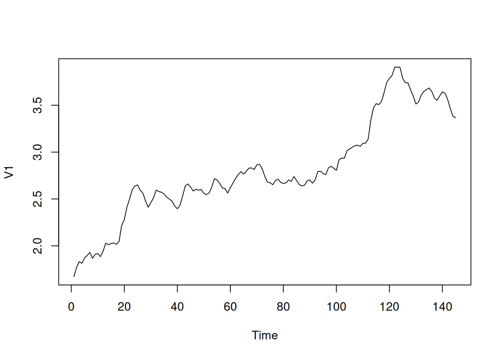

```r
plot(Yt)
```

We model gas prices as a time series $\{ Y_t \}$. The $1$st order difference process, $\{\nabla Y_t\}$, is defined as
$$\nabla Y_t = Y_t - Y_{t-1}$$
and $d$-th order difference process $\{\nabla^d Y_t\}$ is defined as
$$\begin{align*}
\nabla^0 Y_t &= Y_t\\
\nabla^d Y_t &= \nabla \left(\nabla^{d-1} Y_t\right).
\end{align*}$$
where $\nabla^0 Y_t$ is the base case in this recursive definition.

If $\{Y_t\}$ is non-stationary, it generally has a $1$-st or $2$-nd-order difference stationary process. (Higher-order difference processes are not commonly necessary.)

The first-order difference process of gas prices, $\{\nabla Y_t\}$, has the following plots:

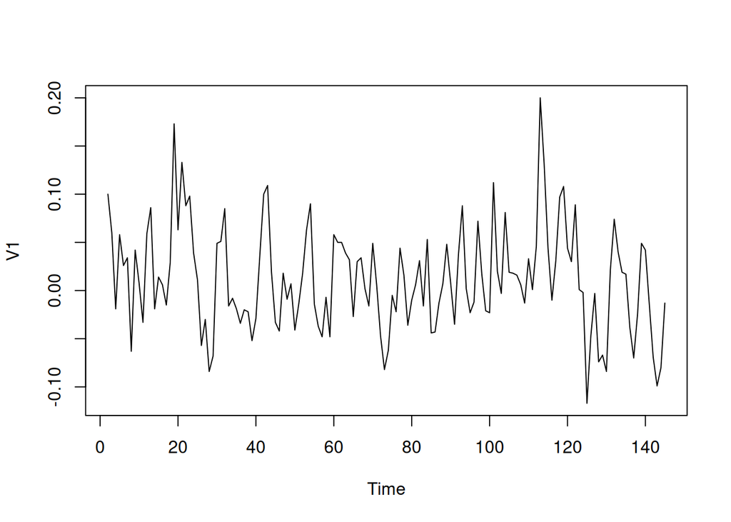

```r
Yt.diff <- diff(Yt,1)
plot(Yt.diff)
```

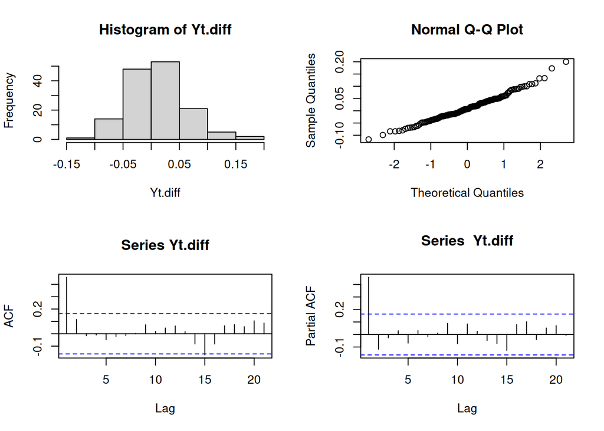

```r
par(mfrow=c(2,2))
hist(Yt.diff)
qqnorm(Yt.diff)
acf(Yt.diff)
pacf(Yt.diff)
```

Looking at the ACF, $\{\nabla Y_t\}$ seems consistent with $\operatorname{MA}$, but the PACF is not what we expect. Likewise, looking at the PACF, $\{\nabla Y_t\}$ is consistent with $\operatorname{AR}$, but the ACF is not what we expect. We have somewhat of a mixture of both.

We plot the EACF to help decide on plausible ARMA models.

```r
eacf(Yt.diff,ar.max=3,ma.max=3)
```

```
## AR/MA
##   0 1 2 3
## 0 x o o o
## 1 x o o o
## 2 x x o o
## 3 x o o o
```

We see that $\operatorname{ARIMA}(0,1,1)$, $\operatorname{ARIMA}(0,1,2)$, and $\operatorname{ARIMA}(1,1,1)$ seem like reasonable candidate models for $\{Y_t\}$.

This does not seem too suprising, given the ACF and PACF plots.

## Part (b)

We evaluate each of the candidate models in the following subsections.

### Model 1: $\operatorname{ARMA}(0,1,2)$

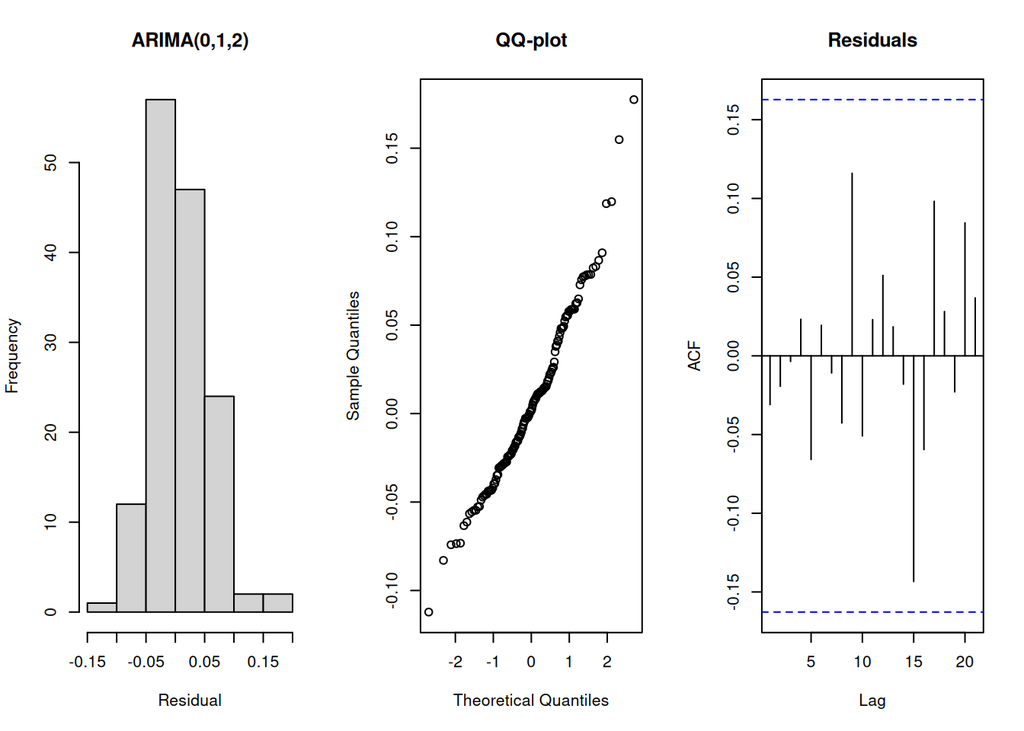

```r
library(forecast)
model1 <- Arima(Yt,order=c(0,1,2))
par(mfrow=c(1,3))
hist(model1$residual,xlab="Residual",main="ARIMA(0,1,2)")
qqnorm(model1$residual,main="QQ-plot")
acf(model1$residual,main="Residuals")
```

The residuals seem like a reasonable approximation of white noise. Next, we do a Box-Ljung test:

```r
K <- 30
p <- 0
q <- 2
Box.test(model1$residuals,
         lag=K,
         type="Ljung-Box",
         fitdf=p+q)
```

```
##
##  Box-Ljung test
##
## data:  model1$residuals
## X-squared = 17.798, df = 28, p-value = 0.9311
```

The observed test statistic is compatible with the hypothesis that the residuals are white noise.

### Model 2: $\operatorname{ARMA}(0,1,1)$

The histogram, QQ-plot, and ACF of the residuals for $\operatorname{ARMA}(0,1,1)$ are given by the following plots.

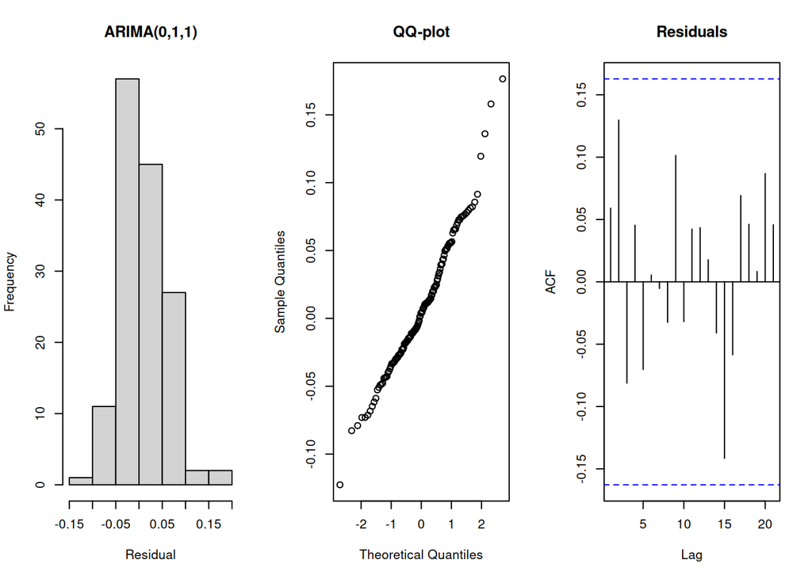

```r
library(forecast)
model2 <- Arima(Yt,order=c(0,1,1))
par(mfrow=c(1,3))
hist(model2$residual,xlab="Residual",main="ARIMA(0,1,1)")
qqnorm(model2$residual,main="QQ-plot")
acf(model2$residual,main="Residuals")
```

The residuals seem like a reasonable approximation of white noise. Next, we do a Box-Ljung test:

```r
p <- 0
q <- 1
Box.test(model2$residuals,
         lag=K,
         type="Ljung-Box",
         fitdf=p+q)
```

```
##
##  Box-Ljung test
##
## data:  model2$residuals
## X-squared = 22.266, df = 29, p-value = 0.809
```

The observed test statistic is compatible with the hypothesis that the residuals are white noise.

### Model 3: $\operatorname{ARMA}(1,1,1)$

The histogram, QQ-plot, and ACF of the residuals for $\operatorname{ARMA}(1,1,1)$ are given by the following plots.

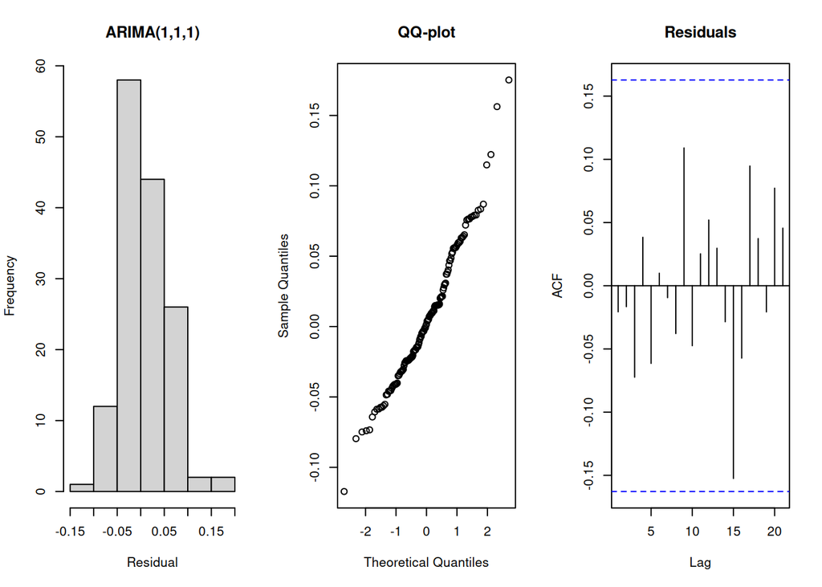

```r
library(forecast)
model3 <- Arima(Yt,order=c(1,1,1))
par(mfrow=c(1,3))
hist(model3$residual,xlab="Residual",main="ARIMA(1,1,1)")
qqnorm(model3$residual,main="QQ-plot")
acf(model3$residual,main="Residuals")
```

The residuals seem like a reasonable approximation of white noise. Next, we do a Box-Ljung test:

```r
p <- 1
q <- 1
Box.test(model3$residuals,
         lag=K,
         type="Ljung-Box",
         fitdf=p+q)
```

```
##
##  Box-Ljung test
##
## data:  model3$residuals
## X-squared = 18.654, df = 28, p-value = 0.9085
```

The observed test statistic is compatible with the hypothesis that the residuals are white noise.

## Part (c)

Both models fit fine, so we will use the model with the minimum AIC.

```r
round(c(model1$aic,model2$aic,model3$aic),3)
```

```
## [1] -459.062 -455.297 -458.351
```

We see that the $\operatorname{ARIMA}(0,1,2)$ model for $\{Y_t\}$ has the minimum AIC of these models with an AIC of -459.062, so we choose this model.

The model summary is given by:

```r
summary(model1)
```

```
## Series: Yt
## ARIMA(0,1,2)
##
## Coefficients:
##          ma1     ma2
##       0.5433  0.1946
## s.e.  0.0843  0.0779
##
## sigma^2 = 0.002345:  log likelihood = 232.53
## AIC=-459.06   AICc=-458.89   BIC=-450.15
##
## Training set error measures:
##                       ME       RMSE        MAE       MPE     MAPE      MASE
## Training set 0.006717107 0.04791789 0.03709482 0.2712316 1.381354 0.8635071
##                     ACF1
## Training set -0.03092411
```

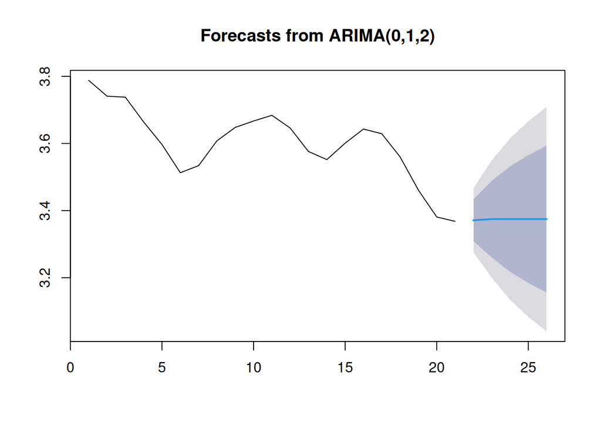

```r
library(forecast)
model1.fc <- forecast(Yt[125:145],model=model1,h=5)
plot(model1.fc)
```

## Additional thoughts: evaluating model performance via data splitting

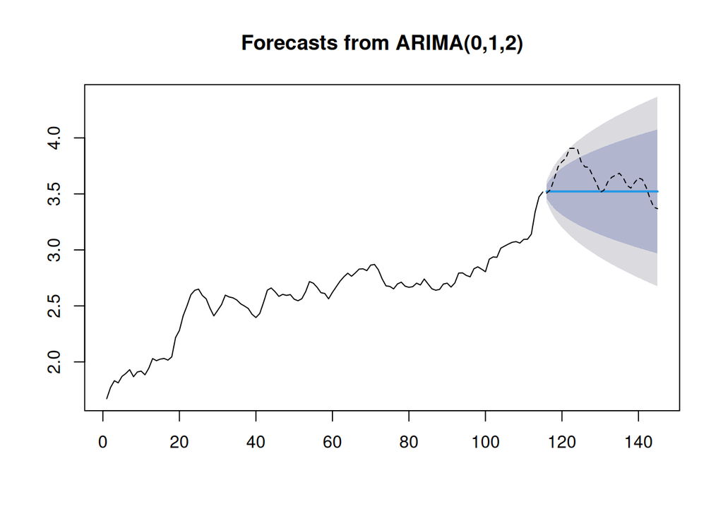

```r
library(forecast)

Yt.train <- ts(Yt[1:115],start=1)
Yt.test <- ts(Yt[116:145],start=116)

model1.train <- Arima(Yt.train,order=c(0,1,2))
model1.train.fc <- forecast(Yt.train,model=model1.train,h=30)

plot(model1.train.fc)
lines(Yt.test, lty=2)
```

Over the long run, the forecast is not bad, but it is not very sensitive to recent history (the positive trend near the end of the training time series). Out of curiosity, we fit a double exponential smoothing model to the training set and then plot its forecast and prediction intervals:

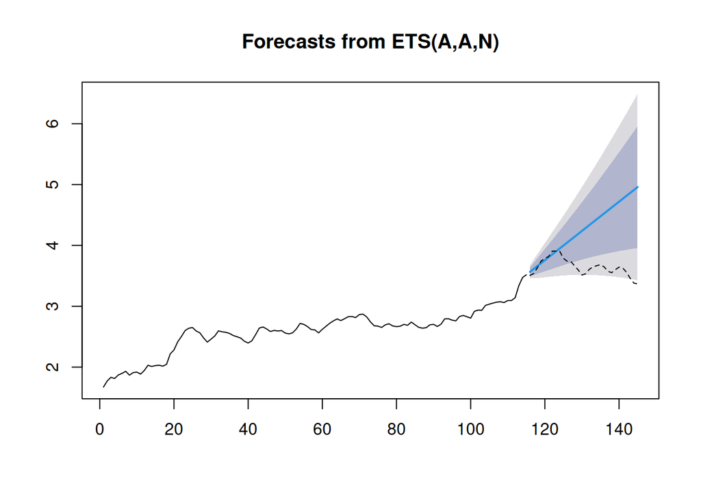

```r
dema.train <- holt(Yt.train,h=30,initial="optimal")
dema.train.fc <- forecast(Yt.train,model=dema.train,h=30)
plot(dema.train.fc)
lines(Yt.test,lty=2)
```

This produces a better short-term forecast that follows the recent trend found at the end of the training time series. As the forecast extends further into the future, it diverges significantly from the test data. (Forecasts will often perform better if any trends are dampened over time, asymptotically converging to a $0$ slope. Such a dampening effect would improve the forecast for this model.)

As a famous quote puts, “It is difficult to make predictions, especially about the future.” Due to the often extreme uncertainty about the future, we tend not to put much stock in long term forecasting (unless the data is highly regular, e.g., we assume the Sun will continue to rise in the morning long into the future). Given this uncertainty and the (we tend to discount far-off rewards), we usually seek a model that we expect to perform well on near-term forecasts. On this metric, we are inclined to prefer the double exponential smoothing model presented above.

# Problem 3

```r
library(TSA)
data(boardings)
log.boardings = boardings[,1]
print(log.boardings)
```

```
##           Jan      Feb      Mar      Apr      May      Jun      Jul      Aug
## 2000                                                                12.49114
## 2001 12.45759 12.51886 12.49804 12.52874 12.52780 12.52162 12.48012 12.52364
## 2002 12.50106 12.52229 12.49063 12.55226 12.54457 12.51336 12.46190 12.51414
## 2003 12.49483 12.53297 12.44026 12.50992 12.50498 12.44860 12.44798 12.48586
## 2004 12.47789 12.54076 12.54592 12.56986 12.57247 12.49189 12.47962 12.51481
## 2005 12.53937 12.58296 12.57383 12.59280 12.58038 12.52468 12.51634 12.57870
## 2006 12.60070 12.62888 12.61389
##           Sep      Oct      Nov      Dec
## 2000 12.58577 12.53457 12.52406 12.39809
## 2001 12.60110 12.58120 12.54482 12.46953
## 2002 12.56313 12.55305 12.54575 12.46286
## 2003 12.58046 12.55216 12.50488 12.42697
## 2004 12.62301 12.59301 12.56187 12.45818
## 2005 12.69752 12.66482 12.63930 12.52714
## 2006
```

## Part (a)

The time series is plotted with:

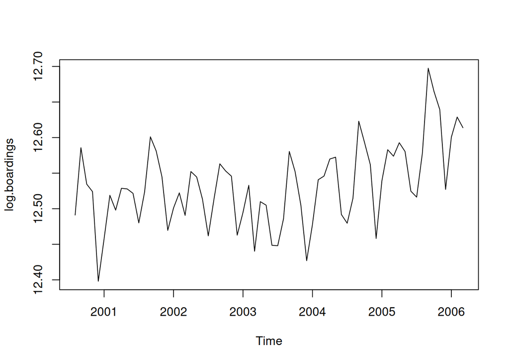

```r
plot(log.boardings)
```

First, there does appear to be a slight seasonable component, although admittedly it is not especially pronounced.

It does not appear to be stationary. We perform the Dickey-Fuller test to further convince ourselves:

```r
tseries::adf.test(log.boardings)
```

```
##
##  Augmented Dickey-Fuller Test
##
## data:  log.boardings
## Dickey-Fuller = -2.163, Lag order = 4, p-value = 0.5089
## alternative hypothesis: stationary
```

At this $p$-value, we do not reject the null hypothesis of non-stationary data. We take the difference and perform the Dickey-Fuller test on that transformation:

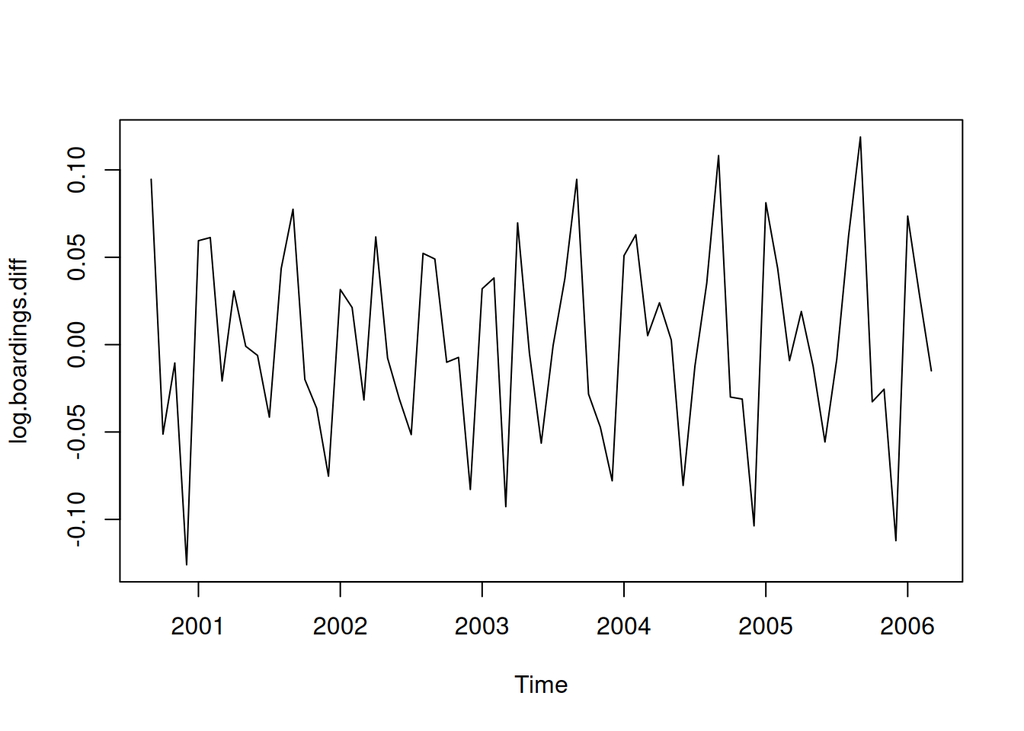

```r
log.boardings.diff <- diff(log.boardings,1)
plot(log.boardings.diff)
```

```r
tseries::adf.test(log.boardings.diff)
```

```
##
##  Augmented Dickey-Fuller Test
##
## data:  log.boardings.diff
## Dickey-Fuller = -6.939, Lag order = 4, p-value = 0.01
## alternative hypothesis: stationary
```

The plot seems to resemble a stationary process. Moreover, the $p$-value of the Dickey-Fuller hypothesis test is around $0.01$, which we consider to be very strong evidence against the null hypothesis of non-stationary data.

## Part (b)

We plot the ACF with:

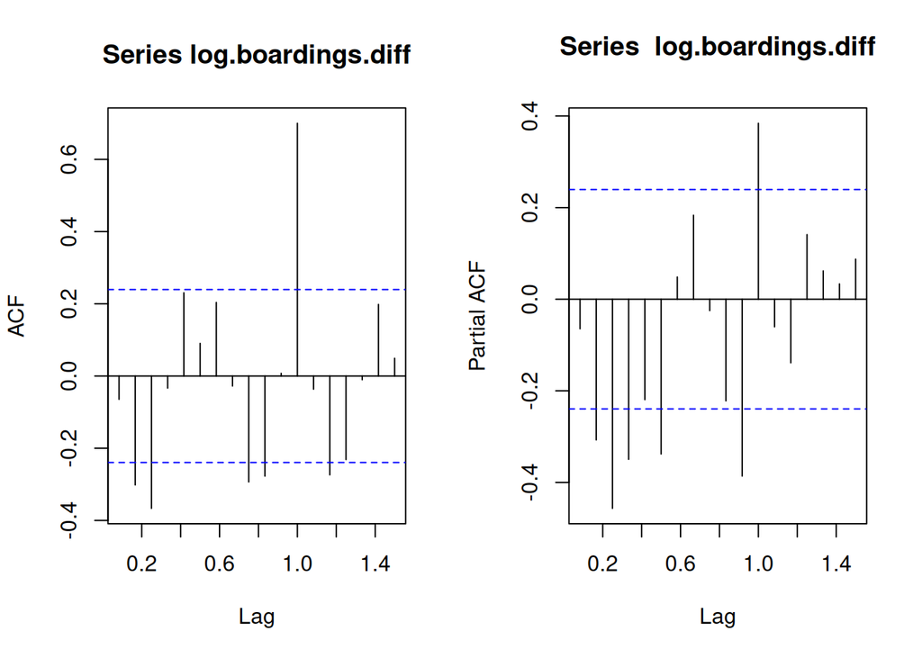

```r
par(mfrow=c(1,2))
acf(log.boardings.diff)
pacf(log.boardings.diff)
```

This ACF diverges from the theoretical ACF of stationary data, but a $2$-nd order difference does not improve the situation. This does not seem too bad.

## Part (c)

We look at the EACF with:

```r
library(TSA)
eacf(log.boardings.diff,ar.max=4,ma.max=4)
```

```
## AR/MA
##   0 1 2 3 4
## 0 o x x o o
## 1 o o x o o
## 2 x x o o o
## 3 x o o o o
## 4 x x o o o
```

This EACF indicates $\operatorname{ARIMA}(p,d=1,q)$ with $(p,q) \in \{(0,0),(1,0),(1,1)\}$.

```r
fit <- auto.arima(log.boardings)
summary(fit)
```

```
## Series: log.boardings
## ARIMA(1,1,0)(0,1,1)[12]
##
## Coefficients:
##           ar1     sma1
##       -0.2919  -0.6089
## s.e.   0.1281   0.2280
##
## sigma^2 = 0.0005886:  log likelihood = 126.56
## AIC=-247.12   AICc=-246.65   BIC=-241.1
##
## Training set error measures:
##                        ME       RMSE       MAE         MPE      MAPE      MASE
## Training set 0.0002045332 0.02141851 0.0154136 0.001459963 0.1230202 0.4291575
##                    ACF1
## Training set 0.04400124
```

```r
print(fit$aic)
```

```
## [1] -247.1219
```

We see that the AIC is $-247.1219$ and the best fit model is of type
$$\operatorname{Seasonal-ARIMA}(p=1,d=1,q=0) \times (P=0,D=1,Q=1).$$
with coefficients given by

```r
coef(fit)
```

```
##        ar1       sma1
## -0.2918525 -0.6088785
```

## Part (d)

We plot a histogram, Q-Q plot, and ACF of the residuals with:

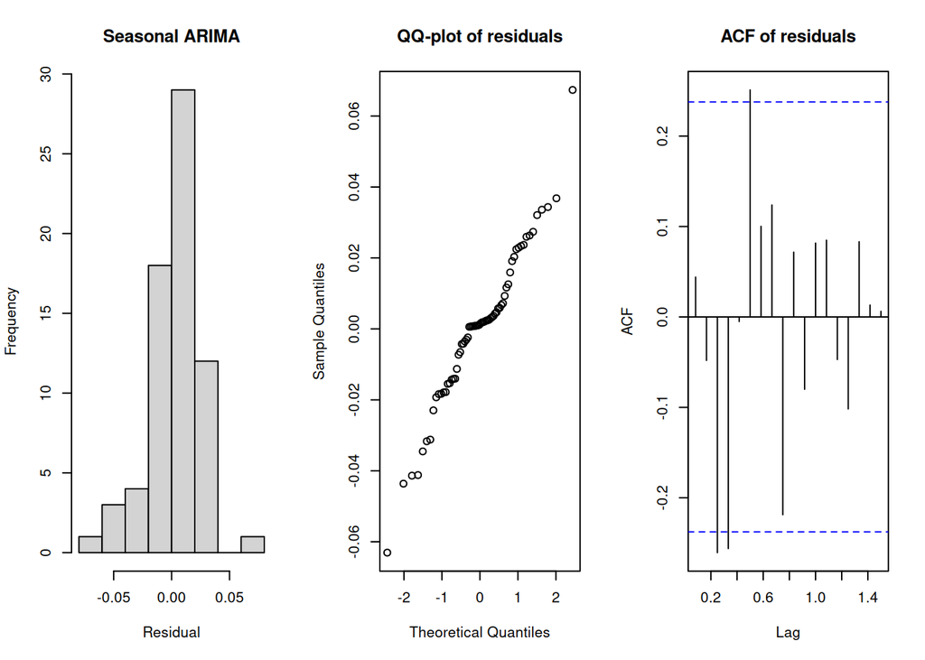

```r
par(mfrow=c(1,3))
hist(fit$residual,xlab="Residual",main="Seasonal ARIMA")
qqnorm(fit$residual,main="QQ-plot of residuals")
acf(fit$residual,main="ACF of residuals")
```

We are not entirely comfortable with these plots representing idealized white noise, but real data sets are not typically going to have a data generating process that is truly distributed according to the ARIMA models, so some discrepencies are expected.

As the saying goes, all models are wrong, but hopefully some are useful. These plots satisfy us that we have sufficiently modeled the significant patterns in the data.

However, we conduct one last hypothesis test on the residuals with:

```r
Box.test(fit$residuals,
         lag=K,
         type="Ljung-Box",
         fitdf=3)
```

```
##
##  Box-Ljung test
##
## data:  fit$residuals
## X-squared = 38.809, df = 27, p-value = 0.06594
```

According to the Box-Ljung test, at a typical significance level $\alpha=0.05$, the residuals are compatible with a white noise process.

### Additional plots

For fun, we do some forecasting with the model:

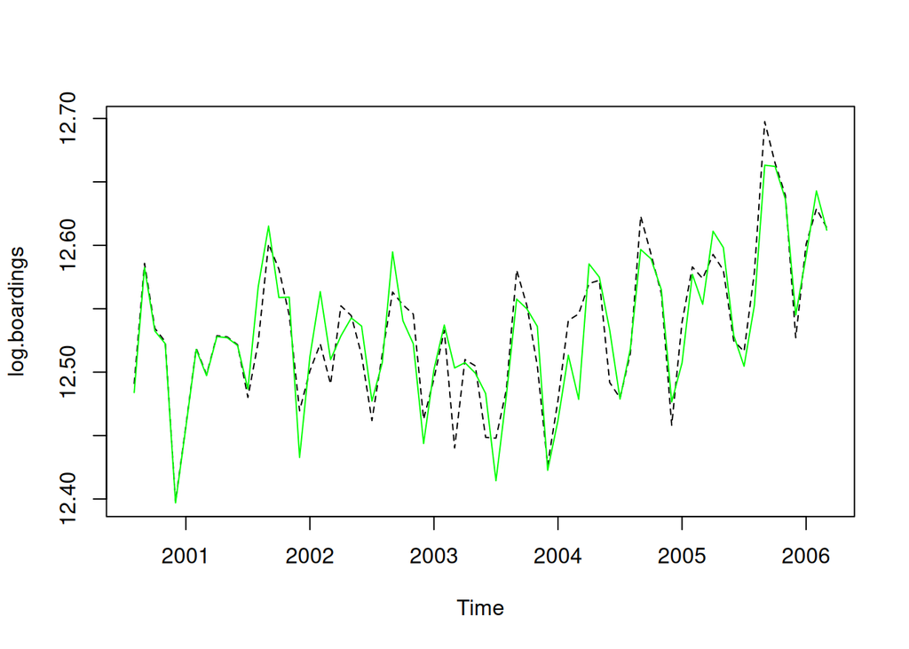

```r
library(forecast)

plot(log.boardings,lty=2)
lines(fit$fitted,col="green")
```

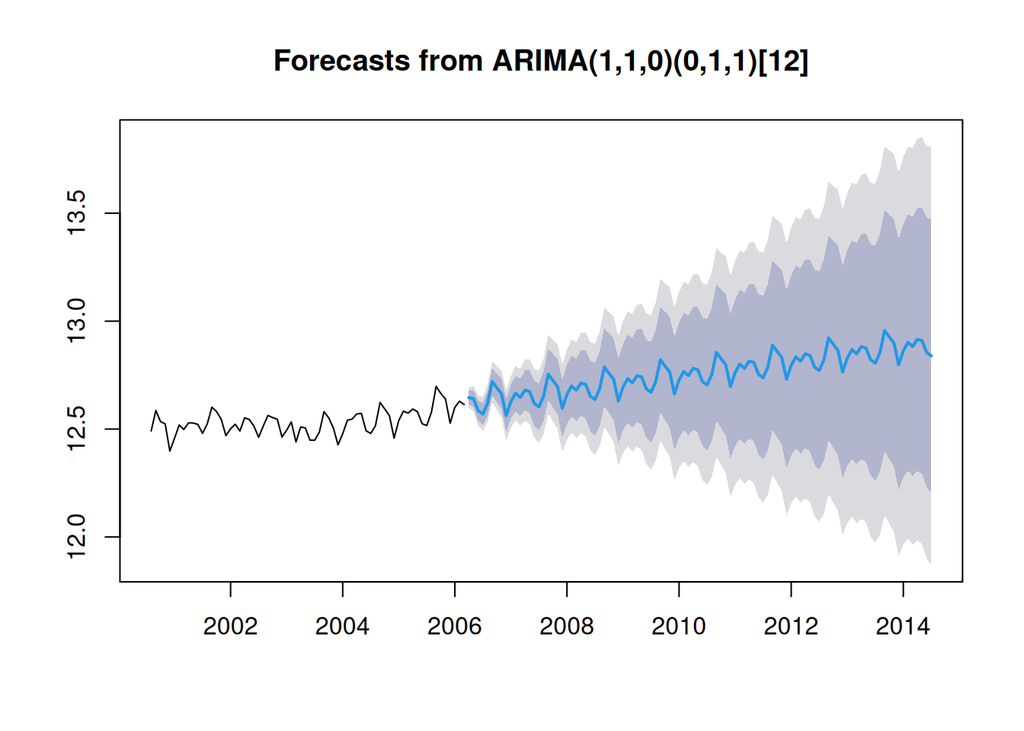

```r
fit.fc <- forecast(log.boardings,model=fit,h=100)
plot(fit.fc)
```

Note that this is with the log-transformed time series, so the forecast of the original time series is given by taking the exponential value of these forecasts.